# Perceptrón

¿Qué es? Es la manera en que nosotros definimos a una neurona artificial.

¿Cómo funciona a nivel biologico y sencillo?

- Dentritas: Son mecanismos receptores de impulsos electricos

  > Recuerda que todas las neuronas se comunican a traves de pequeños impulsos electricos, los cuales son procesados por el axón.
- Axón: Recoge todos los impulsos electricos que son captados también por el núcleo.
- Terminal del axón: Pasan por una serie de procesos a traves de los demás componentes y terminan por la terminal del axón.

Lo podemos ver como una función donde:

- Entran varios impulsos, sucede un proceso (Axón y demas componentes) y al final surge un mecanismo de salida, dependiendo de los procesos que surgieron en la parte anterior.

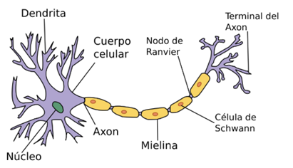

Si nosotros quisieramos modelar de una manera matemática, tendriamos que hacer algún modelo como este:

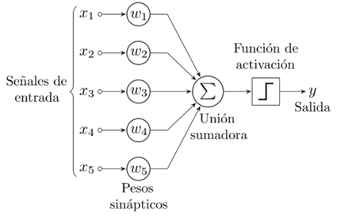

### Explicación:

**Señal de entrada:**

Básicamente en la neurona biológica podemos verlo como un impulso eléctrico, pero en la vida cotidiana es en interpretar características.  
Por ejemplo si estuvieramos hablando de un producto comercial podemos definir las Xn como; color del producto, tamaño, precio, fabricante. Todos van a ser diferentes tipos de señales de entrada (van a ser caracteristicas [features]). Luego van a pasar por una serie de **pesos sinápticos.**

**Peso sináptico:**

Son números encargados de ponderar básicamente, que tan importante es esa señal de entrada a la que esta asociada[Xn].  
Por ejemplo si X1 fuera el precio, entonces la W1 va a valer mucho; digamos 10 o 20.  
Por otro lado supongamos que X2 es el fabricante y no es de mucha importancia entonces al valor de W2 le vamos a asignar uno muy pequeño; digamos 0.3 o 0.1 para quitarle peso, **de ahí viene su nombre; de ponderar la importancia de la señal de entrada.**

**Unión sumadora:**

Nos va a permitir sumar todas esas operaciones de Xn con Wn para tener los resultados. A esta parte se le llama **combinación lineal**

Normalmente las $X_n$ tiene valores binarios $[0,1]$ para indicar un estado, porque los modelos de Machine Learning están preparados para calcular.

A las $\omega _n$ se les asigna un valor dependiendo del peso o importancia que se le quiera dar a la señal de entrada $X_n$.

Si nosotros multiplicamos estas variables $X_1\omega _1$, $X_2\omega _2$, $X_3\omega _3\dots$

Sin darles un sentido, de nada nos sirve así que tenemos que meterlo a una **unión sumadora** $\sum$ y vamos a obtener una **combinación lineal**. Esto quiere decir que se va a convertir en una ecuación lineal, el problema de esto, es que solo es una neurona y tener muchas neuronas va a multiplicar el número de esto y seguirá siendo un comportamiento lineal de linea recta. Y esto no servirá mucho si queremos separar datos, entonces por eso le agregamos una especie de filtro o composición de funciones y llamamos **función de activación** y que le va a dar un comportamiento no lineal. Más adelante veremos **función de activación** y en qué modelos los podemos ocupar.

##### **TODO LO ANTERIOR ES SOLO UNA NEURONA.**

### Rede neuronal artificial

Cada una de los circulos, es un perceptrón o la parte matemática que vimos antes. Las diferentes entradas $X_n$ van a ser procesadas de diferente manera, es decir por capas o columnas verticales y al final nos van a otorgar un resultado de salida

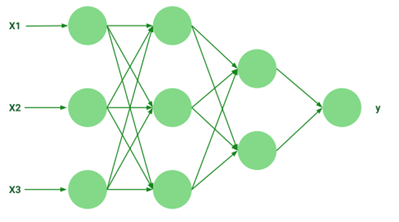

Ejemplo

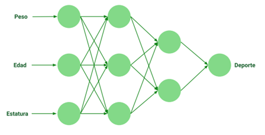

Imaginate que tenemos 3 parametros de una persona, ¿qué va a pasar? que a partir de el procesamiento de los axones va a decidir si una persona es buena para un deporte o nos va a indicar un deporte para el cual es bueno. Todo esto mediante un proceso matemático y otros diferentes.

## Referencias extras:

- [¿Qué es un perceptrón y cómo funciona?](https://www.youtube.com/watch?v=6qulI6A90_Q)
- [Aprende que son las redes neuronales - lista de reproducción](https://www.youtube.com/watch?v=MRIv2IwFTPg&list=PL-Ogd76BhmcB9OjPucsnc2-piEE96jJDQ)